# EGS master catalogue

## Preparation of Legacy Survey data

The catalogue comes from `dmu0_LegacySurvey`.

In the catalogue, we keep:

- The identifier (it's unique in the catalogue);
- The position;
- The stellarity;
- The aperture fluxes. Are these aperture corrected?
- The kron magnitude to be used as total magnitude (no “auto” magnitude is provided).

We don't know when the maps have been observed. We will use the year of the reference paper.

```python
from herschelhelp_internal import git_version
print("This notebook was run with herschelhelp_internal version: \n{}".format(git_version()))
```

```
This notebook was run with herschelhelp_internal version:
44f1ae0 (Thu Nov 30 18:27:54 2017 +0000)
```

```python
%matplotlib inline
#%config InlineBackend.figure_format = 'svg'

import matplotlib.pyplot as plt
plt.rc('figure', figsize=(10, 6))
plt.style.use('ggplot')

from collections import OrderedDict
import os

from astropy import units as u
from astropy import visualization as vis
from astropy.coordinates import SkyCoord
from astropy.table import Column, Table
import numpy as np

from herschelhelp_internal.flagging import  gaia_flag_column
from herschelhelp_internal.masterlist import nb_astcor_diag_plot, nb_plot_mag_ap_evol, \
    nb_plot_mag_vs_apcor, remove_duplicates
from herschelhelp_internal.utils import astrometric_correction, mag_to_flux, aperture_correction, flux_to_mag
```

```python
OUT_DIR =  os.environ.get('TMP_DIR', "./data_tmp")
try:
    os.makedirs(OUT_DIR)
except FileExistsError:
    pass

RA_COL = "legacy_ra"
DEC_COL = "legacy_dec"
```

```python
# Pritine LS catalogue
orig_legacy = Table.read("../../dmu0/dmu0_LegacySurvey/data/LegacySurvey-dr4_EGS.fits")
```

```
WARNING: UnitsWarning: '1/deg^2' did not parse as fits unit: Numeric factor not supported by FITS [astropy.units.core]
WARNING: UnitsWarning: 'nanomaggy' did not parse as fits unit: At col 0, Unit 'nanomaggy' not supported by the FITS standard.  [astropy.units.core]
WARNING: UnitsWarning: '1/nanomaggy^2' did not parse as fits unit: Numeric factor not supported by FITS [astropy.units.core]
WARNING: UnitsWarning: '1/arcsec^2' did not parse as fits unit: Numeric factor not supported by FITS [astropy.units.core]
```

## I - Aperture correction

To compute aperture correction we need to dertermine two parametres: the target aperture and the range of magnitudes for the stars that will be used to compute the correction.

**Target aperture**: To determine the target aperture, we simulate a curve of growth using the provided apertures and draw two figures:

- The evolution of the magnitudes of the objects by plotting on the same plot aperture number vs the mean magnitude.
- The mean gain (loss when negative) of magnitude is each aperture compared to the previous (except for the first of course).

As target aperture, we should use the smallest (i.e. less noisy) aperture for which most of the flux is captures.

**Magnitude range**: To know what limits in aperture to use when doing the aperture correction, we plot for each magnitude bin the correction that is computed and its RMS. We should then use the wide limits (to use more stars) where the correction is stable and with few dispersion.

```python
bands = ["g", "r", "z"]
apertures      = [0,      1,   2,   3,    4,   5,   6,   7]
aperture_sizes = [0.5, 0.75, 1.0, 1.5,  2.0, 3.5, 5.0, 7.0] #arcsec aperture sizes

flux = {}
flux_errors ={}
magnitudes = {}
flux_errors ={}
magnitude_errors = {}
stellarities = {}

flux_to_mag_vect = np.vectorize(flux_to_mag)

for band in bands:
    flux[band] = np.transpose(np.array( orig_legacy["apflux_{}".format(band)], dtype=np.float ))
    flux_errors[band] = np.transpose(np.array( orig_legacy["apflux_ivar_{}".format(band)], dtype=np.float  ))

    magnitudes[band], magnitude_errors[band] = flux_to_mag_vect(flux[band] * 3.631e-6 ,flux_errors[band] * 3.631e-6)

    stellarities[band] = np.full(len(orig_legacy),0., dtype='float32')
    stellarities[band][np.array( orig_legacy["type"]) == "PSF" ] = 1.

    # Some sources have an infinite magnitude
    mask = np.isinf(magnitudes[band])
    magnitudes[band][mask] = np.nan
    magnitude_errors[band][mask] = np.nan




mag_corr = {}
```

### I.a - g band

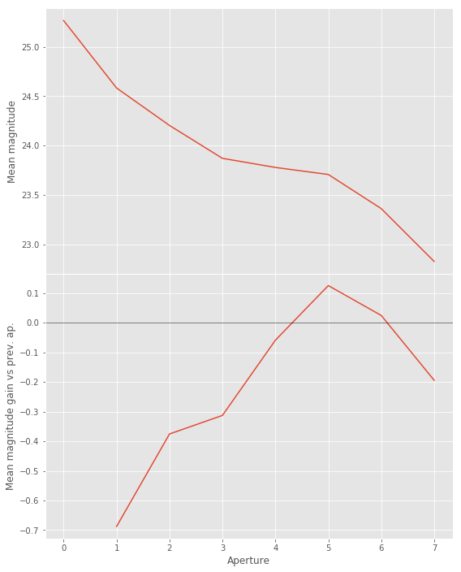

```python
nb_plot_mag_ap_evol(magnitudes['g'], stellarities['g'], labels=apertures)
```

We will use aperture 5 as target.

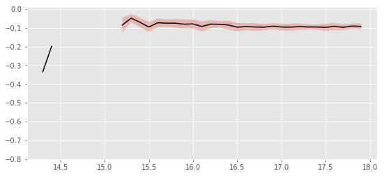

```python
nb_plot_mag_vs_apcor(magnitudes['g'][4],
                     magnitudes['g'][5],
                     stellarities['g'])
```

We will use magnitudes between 17.0 and 18.5

```python
# Aperture correction
mag_corr['g'], num, std = aperture_correction(
    magnitudes['g'][4], magnitudes['g'][5],
    stellarities['g'],
    mag_min=17.0, mag_max=18.5)
print("Aperture correction for g band:")
print("Correction: {}".format(mag_corr['g']))
print("Number of source used: {}".format(num))
print("RMS: {}".format(std))
```

```
Aperture correction for g band:
Correction: -0.09441636798258202
Number of source used: 1084
RMS: 0.01606272315484677
```

### I.b - r band

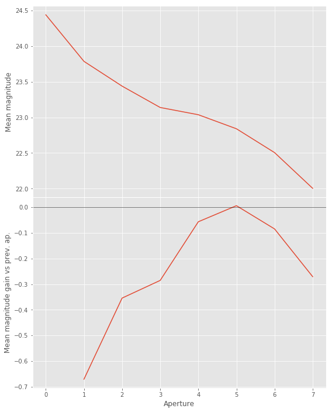

```python
nb_plot_mag_ap_evol(magnitudes['r'], stellarities['r'], labels=apertures)
```

We will use aperture 5 as target.

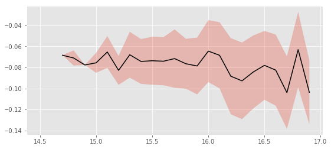

```python
nb_plot_mag_vs_apcor(magnitudes['r'][4],
                     magnitudes['r'][5],
                     stellarities['r'])
```

```python
# Aperture correction
mag_corr['r'], num, std = aperture_correction(
    magnitudes['r'][4], magnitudes['r'][5],
    stellarities['r'],
    mag_min=17.0, mag_max=18.5)
print("Aperture correction for r band:")
print("Correction: {}".format(mag_corr['r']))
print("Number of source used: {}".format(num))
print("RMS: {}".format(std))
```

```
Aperture correction for r band:
Correction: -0.08614945231256144
Number of source used: 1513
RMS: 0.03438196144974404
```

### I.c - z band

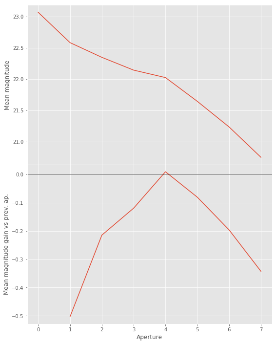

```python
nb_plot_mag_ap_evol(magnitudes['z'], stellarities['z'], labels=apertures)
```

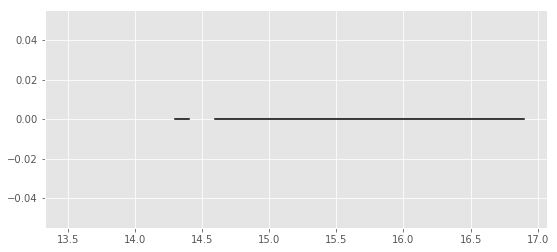

```python
nb_plot_mag_vs_apcor(magnitudes['z'][4],
                     magnitudes['z'][4],
                     stellarities['z'])
```

We use magnitudes between 16.0 and 17.5.

```python
# Aperture correction
mag_corr['z'], num, std = aperture_correction(
    magnitudes['z'][4], magnitudes['z'][5],
    stellarities['z'],
    mag_min=16.0, mag_max=17.5)
print("Aperture correction for z band:")
print("Correction: {}".format(mag_corr['z']))
print("Number of source used: {}".format(num))
print("RMS: {}".format(std))
```

```
Aperture correction for z band:
Correction: -0.033215372542812815
Number of source used: 1183
RMS: 0.012679290276947705
```

## II - Stellarity

Legacy Survey does not provide a 0 to 1 stellarity so we replace items flagged as PSF accpording to the following table:

\begin{equation*} P(star) = \frac{ \prod_{i} P(star)_i }{ \prod_{i} P(star)_i + \prod_{i} P(galaxy)_i } \end{equation*}

where $i$ is the band, and with using the same probabilities as UKDISS:

| HSC flag | UKIDSS flag | Meaning | P(star) | P(galaxy) | P(noise) | P(saturated) |
| --- | --- | --- | --- | --- | --- | --- |
|  | -9 | Saturated | 0.0 | 0.0 | 5.0 | 95.0 |
|  | -3 | Probable galaxy | 25.0 | 70.0 | 5.0 | 0.0 |
|  | -2 | Probable star | 70.0 | 25.0 | 5.0 | 0.0 |
| 0 | -1 | Star | 90.0 | 5.0 | 5.0 | 0.0 |
|  | 0 | Noise | 5.0 | 5.0 | 90.0 | 0.0 |
| 1 | +1 | Galaxy | 5.0 | 90.0 | 5.0 | 0.0 |

```python
stellarities['g'][np.isclose(stellarities['g'], 1.)] = 0.9
stellarities['g'][np.isclose(stellarities['g'], 0.)] = 0.05
```

```python
orig_legacy.add_column(Column(data=stellarities['g'], name="stellarity")) #Stelarites computed earlier
```

## II - Column selection

```python
imported_columns = OrderedDict({
        "objid": "legacy_id",
        "ra": "legacy_ra",
        "dec": "legacy_dec",
        "flux_g": "f_bass_g",
        "flux_ivar_g": "ferr_bass_g",
        "apflux_g": "f_ap_bass_g",
        "apflux_ivar_g": "ferr_ap_bass_g",
        "flux_r": "f_bass_r",
        "flux_ivar_r": "ferr_bass_r",
        "apflux_r": "f_ap_bass_r",
        "apflux_ivar_r": "ferr_ap_bass_r",
        "flux_z": "f_bass_z",
        "flux_ivar_z": "ferr_bass_z",
        "apflux_z": "f_ap_bass_z",
        "apflux_ivar_z": "ferr_ap_bass_z",
        "stellarity": "legacy_stellarity"
    })


catalogue = orig_legacy[list(imported_columns)]
for column in imported_columns:
    catalogue[column].name = imported_columns[column]

epoch = 2017

# Clean table metadata
catalogue.meta = None
```

```python
# Adding flux and band-flag columns
for col in catalogue.colnames:
    if col.startswith('f_'):

        errcol = "ferr{}".format(col[1:])

        #First we take aperture 4 if it is an aperture flux
        if 'ap' in col:
            catalogue[col] = catalogue[col][:, 4]
            catalogue[errcol] = catalogue[errcol][:, 4]

        #Convert nanomaggies to uJy
        # 1 nanomaggy = 1.e-9 maggy
        # 1 maggy = 3631 Jy
        # 1 nanomaggy = 3.631×10-6 Jy
        catalogue[col] = catalogue[col] * 3.631 #* 1.e9
        catalogue[errcol] = (1/np.sqrt(catalogue[errcol])) * 3.631 #* 1.e9
        catalogue[col].unit = u.microjansky
        catalogue[errcol].unit = u.microjansky

        mag, magerror = flux_to_mag(np.array(catalogue[col])* 1.e-6, np.array(catalogue[errcol])* 1.e-6)

        if 'ap' in col:
            mag += mag_corr[col[-1]]
            catalogue[col],catalogue[errcol] = mag_to_flux(mag,magerror)

        # Add magnitudes
        catalogue.add_column(Column(mag , name="m{}".format(col[1:])))
        catalogue.add_column(Column(magerror , name="m{}".format(errcol[1:])))


        # Band-flag column
        if 'ap' not in col:
            catalogue.add_column(Column(np.zeros(len(catalogue), dtype=bool), name="flag{}".format(col[1:])))

# TODO: Set to True the flag columns for fluxes that should not be used for SED fitting.
```

```python
catalogue[:10].show_in_notebook()
```

<Table length=10>

| idx | legacy_id | legacy_ra deg | legacy_dec deg | f_bass_g uJy | ferr_bass_g uJy | f_ap_bass_g | ferr_ap_bass_g | f_bass_r uJy | ferr_bass_r uJy | f_ap_bass_r | ferr_ap_bass_r | f_bass_z uJy | ferr_bass_z uJy | f_ap_bass_z | ferr_ap_bass_z | legacy_stellarity | m_bass_g | merr_bass_g | flag_bass_g | m_ap_bass_g | merr_ap_bass_g | m_bass_r | merr_bass_r | flag_bass_r | m_ap_bass_r | merr_ap_bass_r | m_bass_z | merr_bass_z | flag_bass_z | … |
| --- | --- | --- | --- | --- | --- | --- | --- | --- | --- | --- | --- | --- | --- | --- | --- | --- | --- | --- | --- | --- | --- | --- | --- | --- | --- | --- | --- | --- | --- | --- |
| 0 | 4 | 212.97787369 | 51.6251307707 | 8.90653 | 0.253765 | 5.70184e-06 | 9.72997e-08 | 15.5839 | 0.720777 | 1.09631e-05 | 2.96819e-07 | 21.5006 | 1.35024 | 1.4819e-05 | 1.02269e-06 | 0.05 | 21.5257 | 0.0309348 | False | 22.01 | 0.0185277 | 20.9183 | 0.0502168 | False | 21.3002 | 0.0293956 | 20.5689 | 0.0681844 | False | … |
| 1 | 5 | 212.976552937 | 51.6275352297 | 4.77597 | 0.149811 | 4.67149e-06 | 9.72992e-08 | 12.2625 | 0.385353 | 1.34196e-05 | 2.96821e-07 | 26.8284 | 0.642423 | 2.66382e-05 | 1.02269e-06 | 0.05 | 22.2023 | 0.034057 | False | 22.2264 | 0.0226141 | 21.1786 | 0.0341197 | False | 21.0807 | 0.0240148 | 20.3285 | 0.0259986 | False | … |
| 2 | 6 | 212.978008808 | 51.6269819612 | 2.94933 | 0.236108 | 1.76984e-06 | 9.72997e-08 | 8.38054 | 0.62275 | 5.00338e-06 | 2.96819e-07 | 19.8725 | 1.11098 | 1.07404e-05 | 1.02268e-06 | 0.05 | 22.7257 | 0.0869184 | False | 23.2802 | 0.05969 | 21.5918 | 0.08068 | False | 22.1518 | 0.06441 | 20.6544 | 0.0606984 | False | … |
| 3 | 7 | 212.886407444 | 51.6252654472 | 0.561584 | 0.153655 | 4.44873e-07 | 1.21383e-07 | 2.06535 | 0.284877 | 1.69335e-06 | 2.96819e-07 | 3.34816 | 0.432505 | 3.13047e-06 | 1.02269e-06 | 0.9 | 24.5265 | 0.297068 | False | 24.7794 | 0.296242 | 23.1125 | 0.149757 | False | 23.3281 | 0.190314 | 22.588 | 0.140252 | False | … |
| 4 | 8 | 212.919219822 | 51.6261262237 | 2.97049 | 0.225727 | 1.91153e-06 | 9.73e-08 | 7.54903 | 0.605392 | 5.72076e-06 | 2.9682e-07 | 20.2809 | 1.12382 | 1.41014e-05 | 1.02269e-06 | 0.05 | 22.7179 | 0.082505 | False | 23.1965 | 0.0552658 | 21.7053 | 0.0870702 | False | 22.0064 | 0.0563331 | 20.6323 | 0.0601638 | False | … |
| 5 | 9 | 212.919832467 | 51.6241763083 | 1.11648 | 0.171415 | 1.10276e-06 | 1.14914e-07 | 0.681884 | 0.35665 | 1.06306e-06 | 2.96819e-07 | 2.19854 | 0.60813 | 4.13827e-06 | 1.02269e-06 | 0.05 | 23.7804 | 0.166695 | False | 23.7938 | 0.11314 | 24.3157 | 0.567879 | False | 23.8336 | 0.30315 | 23.0447 | 0.300322 | False | … |
| 6 | 10 | 212.908598967 | 51.6248258823 | 0.271494 | 0.152331 | 5.24418e-07 | 1.06499e-07 | 0.563183 | 0.279048 | 5.6112e-07 | 2.9682e-07 | 5.05914 | 0.432956 | 3.96118e-06 | 1.02268e-06 | 0.9 | 25.3156 | 0.609189 | False | 24.6008 | 0.220491 | 24.5234 | 0.537964 | False | 24.5274 | 0.57433 | 22.1398 | 0.0929161 | False | … |
| 7 | 12 | 213.00052631 | 51.6241059712 | 2.29832 | 0.137976 | 2.38101e-06 | 1.00536e-07 | 3.21071 | 0.294019 | 2.91559e-06 | 2.9682e-07 | 5.20867 | 0.40929 | 2.93118e-06 | 1.02269e-06 | 0.9 | 22.9965 | 0.0651804 | False | 22.9581 | 0.0458441 | 22.6335 | 0.0994257 | False | 22.7382 | 0.110533 | 22.1082 | 0.0853156 | False | … |
| 8 | 13 | 213.015038246 | 51.6239639116 | 0.950261 | 0.148543 | 1.27126e-06 | 9.90667e-08 | 0.501666 | 0.360845 | 9.52239e-07 | 2.96821e-07 | -0.865408 | 0.56568 | 1.52094e-06 | 1.02269e-06 | 0.05 | 23.9554 | 0.169721 | False | 23.6394 | 0.084609 | 24.649 | 0.780963 | False | 23.9531 | 0.338433 | nan | -0.709699 | False | … |
| 9 | 14 | 213.0140402 | 51.624368755 | 0.733751 | 0.125846 | 9.01264e-07 | 9.78857e-08 | 1.34969 | 0.28591 | 1.84723e-06 | 2.96818e-07 | 3.13665 | 0.39297 | 3.13573e-06 | 1.02269e-06 | 0.9 | 24.2361 | 0.186215 | False | 24.0129 | 0.117921 | 23.5744 | 0.229995 | False | 23.2337 | 0.17446 | 22.6588 | 0.136025 | False | … |

## III - Removal of duplicated sources

We remove duplicated objects from the input catalogues.

```python
SORT_COLS = [
        'merr_ap_bass_g', 'merr_ap_bass_r', 'merr_ap_bass_z']
FLAG_NAME = 'legacy_flag_cleaned'

nb_orig_sources = len(catalogue)

catalogue = remove_duplicates(
    catalogue, RA_COL, DEC_COL,
    sort_col= SORT_COLS,
    flag_name=FLAG_NAME)

nb_sources = len(catalogue)

print("The initial catalogue had {} sources.".format(nb_orig_sources))
print("The cleaned catalogue has {} sources ({} removed).".format(nb_sources, nb_orig_sources - nb_sources))
print("The cleaned catalogue has {} sources flagged as having been cleaned".format(np.sum(catalogue[FLAG_NAME])))
```

```
The initial catalogue had 166758 sources.
The cleaned catalogue has 163539 sources (3219 removed).
The cleaned catalogue has 3171 sources flagged as having been cleaned
```

## III - Astrometry correction

We match the astrometry to the Gaia one. We limit the Gaia catalogue to sources with a g band flux between the 30th and the 70th percentile. Some quick tests show that this give the lower dispersion in the results.

```python
gaia = Table.read("../../dmu0/dmu0_GAIA/data/GAIA_EGS.fits")
gaia_coords = SkyCoord(gaia['ra'], gaia['dec'])
```

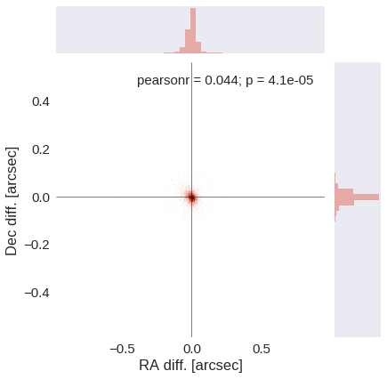

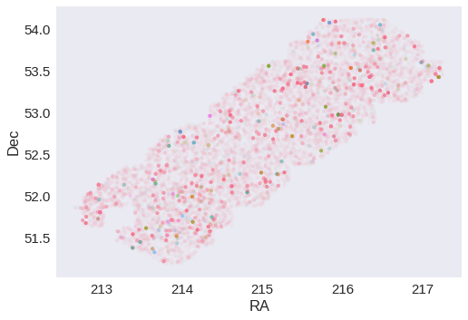

```python
nb_astcor_diag_plot(catalogue[RA_COL], catalogue[DEC_COL],
                    gaia_coords.ra, gaia_coords.dec)
```

```python
delta_ra, delta_dec =  astrometric_correction(
    SkyCoord(catalogue[RA_COL], catalogue[DEC_COL]),
    gaia_coords
)

print("RA correction: {}".format(delta_ra))
print("Dec correction: {}".format(delta_dec))
```

```
RA correction: -0.003632177259760283 arcsec
Dec correction: 0.004341531230522833 arcsec
```

```python
catalogue[RA_COL].unit = u.deg
catalogue[DEC_COL].unit = u.deg
catalogue[RA_COL] = catalogue[RA_COL] +  delta_ra.to(u.deg)
catalogue[DEC_COL] = catalogue[DEC_COL] +  delta_dec.to(u.deg)
```

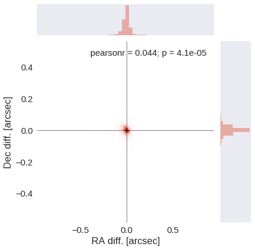

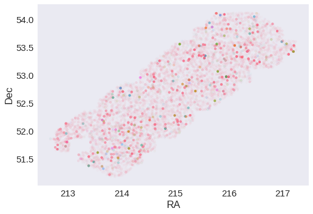

```python
nb_astcor_diag_plot(catalogue[RA_COL], catalogue[DEC_COL],
                    gaia_coords.ra, gaia_coords.dec)
```

## IV - Flagging Gaia objects

```python
catalogue.add_column(
    gaia_flag_column(SkyCoord(catalogue[RA_COL], catalogue[DEC_COL]), epoch, gaia)
)
```

```python
GAIA_FLAG_NAME = "legacy_flag_gaia"

catalogue['flag_gaia'].name = GAIA_FLAG_NAME
print("{} sources flagged.".format(np.sum(catalogue[GAIA_FLAG_NAME] > 0)))
```

```
9145 sources flagged.
```

# V - Saving to disk

```python
catalogue.write("{}/LegacySurvey.fits".format(OUT_DIR), overwrite=True)
```